# Fitting SIR Model to Influenza in a Boarding School data set using Generalised Least Squares

Nik Cunniffe

9 December 2021

## Introduction

This is a markdown showing how the SIR model can be fitted using generalised least squares in a case where it is identifiable.

## Reading in data

Read in the data (either the path `baseDir` will need to be changed to run on a different computer, or you will have to knit the file from within the same directory as the `Boarding.xlsx` file)

```r
###
# Set working directory
###
# baseDir <- "your working directory"
# setwd(baseDir)

allData <- read.xls("Boarding.xlsx")
head(allData)
```

```
##   x   y
## 1 0   1
## 2 1   6
## 3 2  26
## 4 3  73
## 5 4 222
## 6 5 293
```

## Setting up known parameters

We are only fitting $\beta$ and $\gamma$, with the remaining parameters and initial conditions being known. Note that throughout the code it is assumed that there are no recovered individuals initially, i.e. $R(0) = 0$, and that all infecteds are observed, i.e. $k = 1$.

```r
S0 <- 762
I0 <- 1
N <- 763
```

## Running the generalised least squares algorithm

Before running the loop, we need to set parameters controlling how the generalised least squares iteration will work.

```r
rho <- 1           # form of the weighting
nFits <- 25          # how many distinct fits to attempt on each step of the GLS algorithm
maxIts <- 20         # alternative stopping condition; if not converged within maxIts iteration, then stop
sqParamDiffThresh <- 1e-8  # criterion that successive estimates of $\Theta_k$ are "sufficiently close"
```

Do the iteration (note that if `rho = 0` – i.e. ordinary least squares – the loop only ever takes a single step, since the fit does not change)

```r
thisRes <- list(beta = 0, gamma = 0, weights = NA)
thisStep <- 0
sqParamDiff <- 1
while(thisStep <= maxIts & sqParamDiff > sqParamDiffThresh)
{
  nextRes <- singleStep(thisRes$beta,
                        thisRes$gamma,
                        thisRes$weights,
                        (thisStep==0),
                        nFits = nFits,
                        dataT = allData$x,
                        dataObs = allData$y,
                        trueSZero = S0,
                        trueIZero = I0,
                        trueN = N,
                        rho = rho)

  sqParamDiff <- (thisRes$beta-nextRes$beta)^2 +
                  (thisRes$gamma-nextRes$gamma)^2

  thisRes <- nextRes

  print("***")
  print(paste("After step",thisStep))
  print(paste("beta =",thisRes$beta))
  print(paste("gamma =",thisRes$gamma))
  print(paste("lSq =",thisRes$lSq))
  print(paste("sqParamDiff =",sqParamDiff))
  print("***")
  if(sqParamDiff > sqParamDiffThresh)
  {
    thisStep <- thisStep + 1
  }
  if(rho == 0)
  {
    sqParamDiff <- 0
    print("Short circuit iteration since rho = 0")
  }
}
```

```
## [1] "***"
## [1] "After step 0"
## [1] "beta = 1.96048933840676"
## [1] "gamma = 0.475143020238218"
## [1] "lSq = 4892.64189161484"
## [1] "sqParamDiff = 4.06927933568768"
## [1] "***"
## [1] "***"
## [1] "After step 1"
## [1] "beta = 2.08078976160719"
## [1] "gamma = 0.526405883456197"
## [1] "lSq = 1.01868146315084"
## [1] "sqParamDiff = 0.0171000729675071"
## [1] "***"
## [1] "***"
```

[output cut: 34 more lines]

## Calculate and report the confidence intervals

```r
confInt <- calcCI(estBeta = thisRes$beta,
                        estGamma = thisRes$gamma,
                        dataT=allData$x,
                        dataObs = allData$y,
                        trueSZero = S0,
                        trueIZero = I0,
                        trueN = N,
                        rho = rho)

s <- sprintf("rho=%.2f beta=%.4f+-%.4f gamma=%.4f+-%.4f (converged after %d iterations)",
             rho,
             thisRes$beta,
             confInt$betaCI,
             thisRes$gamma,
             confInt$gammaCI,
             thisStep)

print(s)
```

```
## [1] "rho=1.00 beta=2.0851+-0.1705 gamma=0.5494+-0.0992 (converged after 6 iterations)"
```

```r
s <- sprintf("Condition number=%.4f",confInt$condNumFIM)
print(s)
```

```
## [1] "Condition number=3.5774"
```

```r
print("The covariance matrix is")
```

```
## [1] "The covariance matrix is"
```

```r
print(confInt$covMat)
```

```
##              [,1]         [,2]
## [1,]  0.006126214 -0.001107374
## [2,] -0.001107374  0.002074481
```

## Plot best fitting model

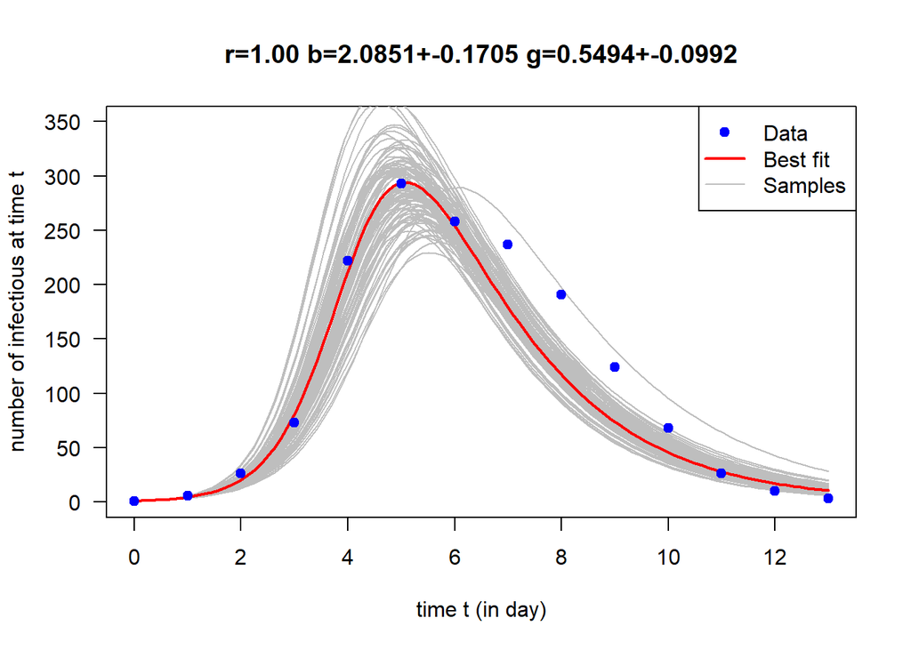

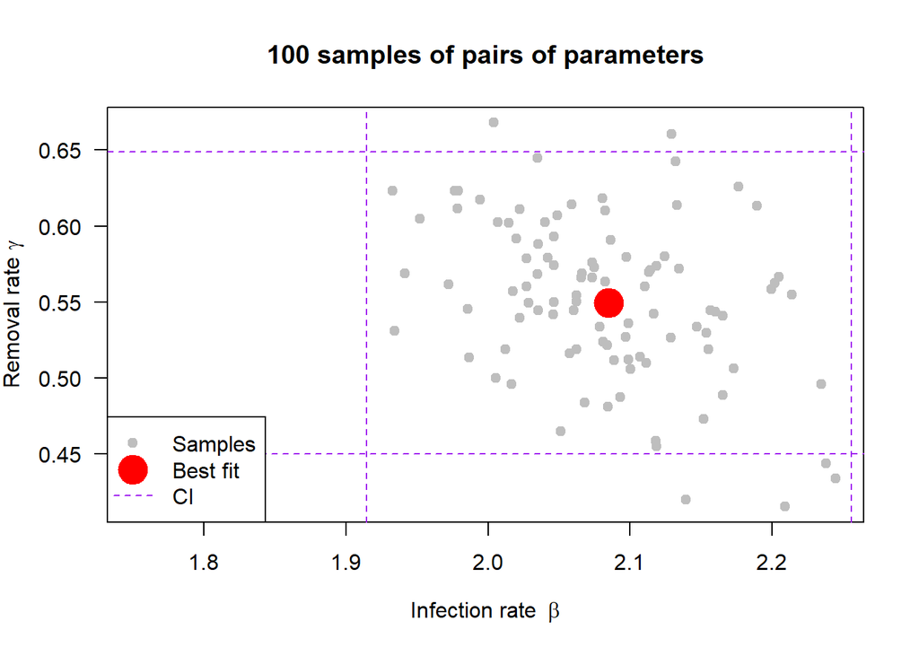

```r
plotFit(allData,100,thisRes,confInt,rho,NA)
```

## Utility functions

The code as shown above uses the following utility functions to actually do the calculations

```r
###
# Right hand side of the ODE for the model
###
sirModel <- function(t, y, p)
{
  S <- y[1]
  I <- y[2]

  dS <- -p$beta*S*I/p$N
  dI <- p$beta*S*I/p$N - p$gamma*I

  return(list(c(dS,dI)))
}

###
# Function which calculates the squared error for generalised least squares
#
# Note that we estimate transformed parameters
#     par[1] = log(R_0-1)
#     par[2] = log(gamma)
# to avoid having to constrain the optimiser
#
# Since R_0 = beta/gamma the parameters of interest follow by back-transforming
#   gamma = exp(par[2])
#   beta  = gamma * (1 + exp(par[1]))
###

glsBoarding <- function(par,dataT,dataObs,dataW,trueSZero,trueIZero,trueN)
{
  thisR0MinusOne <- exp(par[1])   # estimate log(R_0 - 1)
  thisGamma <- exp(par[2])        # estimate log(gamma)

  thisBeta <- thisGamma * (1 + thisR0MinusOne)

  myParms <- list(
    beta = thisBeta,
    gamma = thisGamma,
    N = trueN
  )

  myInit <- c(S=trueSZero, I=trueIZero)

  myOutput <- ode(y = myInit,
                  times = dataT,
                  func = sirModel,
                  parms = myParms)

  fitI <- myOutput[,3]

  sqErr <- 0
  for(i in 1:length(dataT))
  {
    sqErr <- sqErr + dataW[i] * (fitI[i] - dataObs[i])^2
  }
  errFunc <- sqErr

  return(errFunc)
}

###
# Perform a single step of the GLS optimisation
###
singleStep <- function(startBeta,
                       startGamma,
                       startWeights,
                       initStep,
                       nFits,
                       dataT,
                       dataObs,
                       trueSZero,
                       trueIZero,
                       trueN,
                       rho)
{

  allBeta <- numeric(nFits)
  allGamma <- numeric(nFits)
  allLS <- numeric(nFits)

  #
  # Do nFit separate fits
  #
  for(i in 1:nFits)
  {
    if(initStep)
    {
      # if doing the initial step, randomly choose baseline start value and set weights to 1
      thisStartGamma <- runif(1,min=0.1,max=1)
      thisStartR0MinusOne <- runif(1,min=0.1,max=1)
      startWeights <- rep(1,length(dataT))
    }else{
      # otherwise start from "quite near" to the estimate from the previous step
      thisStartGamma <- startGamma * runif(1,min=0.9,max=1.1)
      thisStartR0MinusOne <- (startBeta/startGamma - 1) * runif(1,min=0.9,max=1.1)
    }

    glsParams <- optim(par = c(log(thisStartR0MinusOne),
                               log(thisStartGamma)),
                               fn = glsBoarding,
                               dataT = dataT,
                               dataObs = dataObs,
                               dataW = startWeights,
                               trueSZero = trueSZero,
                               trueIZero = trueIZero,
                               trueN = trueN,
                               control=list(maxit=10000))
    if(glsParams$convergence == 0)
    {
      allGamma[i] <- exp(glsParams$par[2])
      allBeta[i] <- allGamma[i] * ( 1 + exp(glsParams$par[1]))
      allLS[i] <- glsParams$value
    }else{
      allBeta[i] <- NA
      allGamma[i] <- NA
      allLS[i] <- NA
    }
  }

  #
  # Select the best fitting of all nFits attempts
  # and re-run the ODE to calculate the weights for the
  # next step of the optimisation
  #
  minIDX <- which(allLS==min(allLS,na.rm=T))[1]

  bestBeta <- allBeta[minIDX]
  bestGamma <- allGamma[minIDX]
  bestLS <- allLS[minIDX]

  myParms <- list(
    beta = bestBeta,
    gamma = bestGamma,
    N = trueN
  )

  myInit <- c(S=trueSZero, I=trueIZero)

  myOutput <- ode(y = myInit,
                  times = dataT,
                  func = sirModel,
                  parms = myParms)

  fitI <- myOutput[,3]

  bestWeights <- 1.0/fitI^(2*rho)
  retVal <- list(beta = bestBeta,
                 gamma = bestGamma,
                 weights = bestWeights,
                 lSq = bestLS)
}

###
# Right hand side of the ODE for the Fisher Information Matrix
###
fimRHS <- function(t, y, p)
{
  S <- y[1]
  I <- y[2]

  z <- matrix(c(y[3],
                y[4],
                y[5],
                y[6]),
              nrow=2,
              ncol=2,
              byrow=F) # byrow = F -> fills in order top-left, bottom-left, top-right, bottom-right

  A <- matrix(c(-p$beta * I / N,          # top-left
                p$beta * I / N,          # bottom-left
                -p$beta * S / N,          # top-right
                p$beta * S / N - p$gamma), # bottom-right
              nrow=2,
              ncol=2,
              byrow=F)

  B <- matrix(c(-S * I / p$N,
                S * I / p$N,
                0,
                -I),
              nrow=2,
              ncol=2,
              byrow=F)

  xDot <- sirModel(t, c(S=S,I=I), p)

  zDot <- A %*% z + B

  return(list(c(xDot[[1]][1],xDot[[1]][2],zDot[1,1],zDot[2,1],zDot[1,2],zDot[2,2])))
}

###
# Use the Fisher Information Matrix to extract confidence intervals
###
calcCI <- function(estBeta,
                    estGamma,
                    dataT,
                    dataObs,
                    trueSZero,
                    trueIZero,
                    trueN,
                    rho)
{
  #
  # calculate sigmaHatSqGLS by first solving the system
  # with the estimated parameters, to find the weights
  #
  myParms <- list(beta = estBeta,
                  gamma = estGamma,
                  N = trueN)

  myInit <- c(S=trueSZero,
              I=trueIZero)

  myOutput <- ode(y = myInit,
                  times = dataT,
                  func = sirModel,
                  parms = myParms)

  fitI <- myOutput[,3]

  sqErr <- 0
  numPts <- length(dataT)
  w <- length(dataT)
  for(i in 1:numPts)
  {
    sqErr <- sqErr + (fitI[i] - dataObs[i])^2 / fitI[i]^(2*rho)
    w[i] <- 1.0 / fitI[i]^(2*rho)
  }
  sigmaHatSqGLS <- sqErr/(numPts - 2)

  #
  # Calculate confidence intervals using FIM
  #
  myInitLong <- c(S=S0,
                  I=I0,
                  z_11=0,
                  z_21=0,
                  z_12=0,
                  z_22=0)

  myOutputLong <- ode(y = myInitLong,
                  times = dataT,
                  func = fimRHS,
                  parms = myParms)

  m<-rbind(myOutputLong[,"z_21"],
           myOutputLong[,"z_22"])

  fim_11 <- 0
  fim_21 <- 0
  fim_12 <- 0
  fim_22 <- 0

  for(i in 1:numPts)
  {
    thisM <- m[,i]
    fim_11 <- fim_11 + w[i] * thisM[1] * thisM[1]
    fim_21 <- fim_21 + w[i] * thisM[2] * thisM[1]
    fim_12 <- fim_12 + w[i] * thisM[1] * thisM[2]
    fim_22 <- fim_22 + w[i] * thisM[2] * thisM[2]
  }

  fimMat <- matrix(c(fim_11,
                     fim_21,
                     fim_12,
                     fim_22),
                   nrow=2,
                   ncol=2,
                   byrow=F)

  fimMat <- fimMat / sigmaHatSqGLS

  covMat <- solve(fimMat)

  tCrit <- qt(0.975, df = (numPts - 2))
  betaCI <- tCrit * sqrt(covMat[1,1])
  gammaCI <- tCrit * sqrt(covMat[2,2])

  condNumFIM <- kappa(fimMat,exact=T)

  return(list(sigmaHatSqGLS=sigmaHatSqGLS,
              betaCI=betaCI,
              gammaCI=gammaCI,
              covMat=covMat,
              condNumFIM=condNumFIM))
}

#
# Plot the data, the best fit and a sample of numPlots runs using estimated parameters
# Note here we sample from the 2 dimension distribution (i.e. including covariance)
#
# If outFile is NA, then plot to the screen (or insert into results of Markdown)
#
plotFit <- function(allData,
                    numPlots,
                    thisRes,
                    confInt,
                    rho,
                    outFile)
{
  #
  # Plot out the data
  #
  if(!is.na(outFile))
  {
    outFile <- sprintf("%s.png",outFile)
    png(outFile,width=560,height=560)
    par(cex.lab=2)
    par(cex.axis=2)
    par(cex.main=2)
    par(mgp=c(5, 2, 0))
    par(mar=c(7, 7, 2, 2))
  }
  par(las=1)
  plot(allData$x,
       allData$y,
       pch=19,
       col="blue",
       xlab = "time t (in day)",
       ylab = "number of infectious at time t",
       xlim=c(0,13),
       ylim=c(0,350))

  #
  # take samples from the distribution of parameters
  # and plot in grey
  #

  thisDF <- length(allData$x)-2
  sampledParams <- rmvt(numPlots,
                        delta=c(thisRes$beta,thisRes$gamma),
                        sigma=confInt$covMat,
                        type="shifted",
                        df=thisDF)

  myInit <- c(S=S0,
              I=I0)
  myTimes <- seq(0,13,length.out=100)
  for(z in 1:numPlots)
  {
    myParms <- list(
      beta = sampledParams[z,1],
      gamma = sampledParams[z,2],
      N = N
    )

    myOutput <- ode(y = myInit,
                    times = myTimes,
                    func = sirModel,
                    parms = myParms)

    lines(myOutput[,"time"],myOutput[,"I"],col="gray")
  }

  #
  # plot for best fit
  #
  myParms <- list(
    beta = thisRes$beta,
    gamma = thisRes$gamma,
    N = N
  )

  myOutput <- ode(y = myInit,
                  times = myTimes,
                  func = sirModel,
                  parms = myParms)

  lines(myOutput[,"time"],myOutput[,"I"],col="red",lwd=2)


  #
  # replot data itself to ensure emphasised
  #
  points(allData$x,
         allData$y,
         pch=19,
         col="blue")

  legend("topright",c("Data","Best fit","Samples"),col=c("blue","red","grey"),lwd=c(NA,2,1),pch=c(19,NA,NA),cex=1)

  s <- sprintf("r=%.2f b=%.4f+-%.4f g=%.4f+-%.4f",
               rho,
               thisRes$beta,
               confInt$betaCI,
               thisRes$gamma,
               confInt$gammaCI)

  title(s)

  plot(sampledParams[,1],
       sampledParams[,2],
       xlab=expression("Infection rate "~beta),
       ylab=expression("Removal rate "~gamma),
       main=paste(numPlots,"samples of pairs of parameters"),
       pch = 19,
       col="grey")

  lines(c(thisRes$beta-confInt$betaCI,thisRes$beta-confInt$betaCI),
        c(par("usr")[3],par("usr")[4]),
        col="purple",
        lty=2)

  lines(c(thisRes$beta+confInt$betaCI,thisRes$beta+confInt$betaCI),
        c(par("usr")[3],par("usr")[4]),
        col="purple",
        lty=2)

  lines(c(par("usr")[1],par("usr")[2]),
        c(thisRes$gamma-confInt$gammaCI,thisRes$gamma-confInt$gammaCI),
        col="purple",
        lty=2)

  lines(c(par("usr")[1],par("usr")[2]),
        c(thisRes$gamma+confInt$gammaCI,thisRes$gamma+confInt$gammaCI),
        col="purple",
        lty=2)

  points(thisRes$beta,thisRes$gamma,pch=19,cex=3,col="red")

  legend("bottomleft",
         c("Samples","Best fit","CI"),
         col=c("grey","red","purple"),
         lwd=c(NA,NA,1),
         lty=c(NA,NA,2),
         pch=c(19,19,NA),
         pt.cex=c(1,3,1))


  if(!is.na(outFile))
  {
    dev.off()
  }
}
```